# P4 Explore and Summarize Data

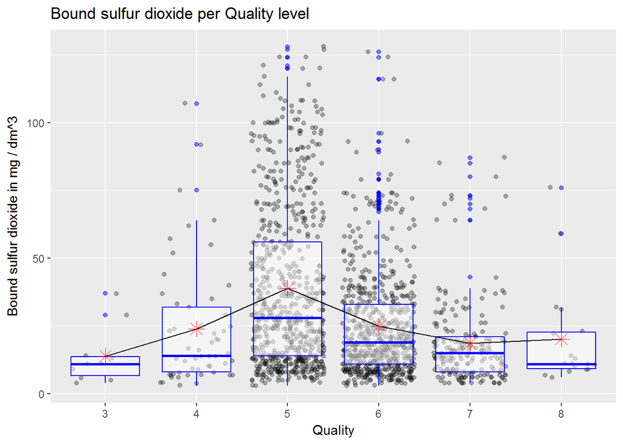

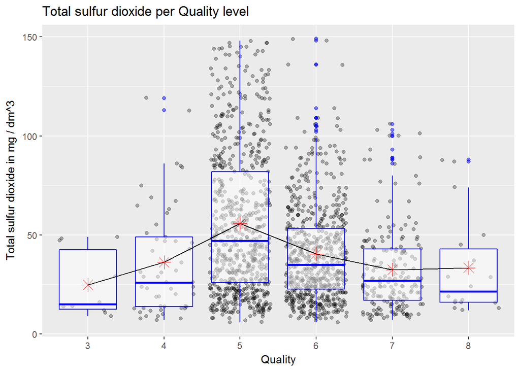

Free and bound (and therefore total) sulfur dioxide does not show a linear relationship with quality, but a normal-like distribution: low levels of SO2 for low and high quality wines and higher levels of SO2 for the average quality wines. I wonder if in the right combination with other variables like alcohol, sulphates and/or PH, SO2 can improve or worsen a wine.

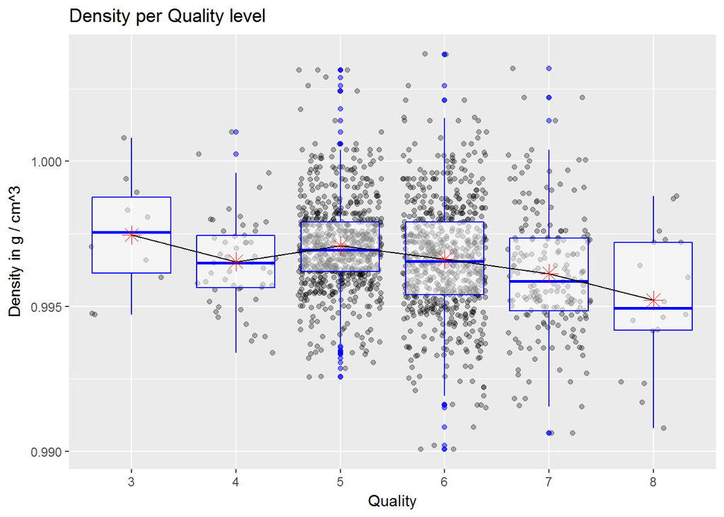

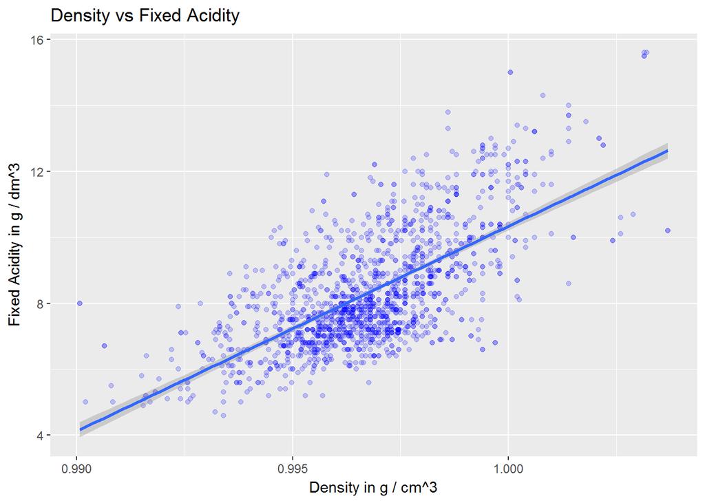

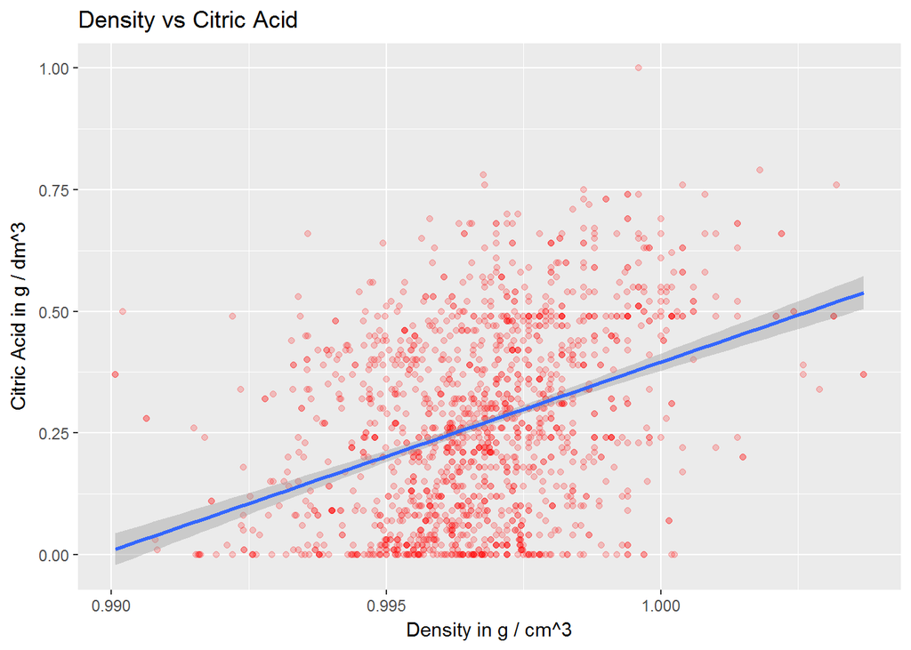

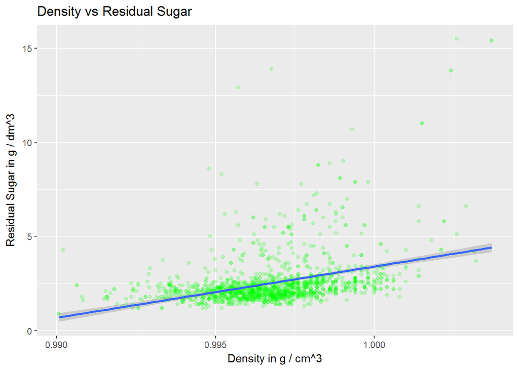

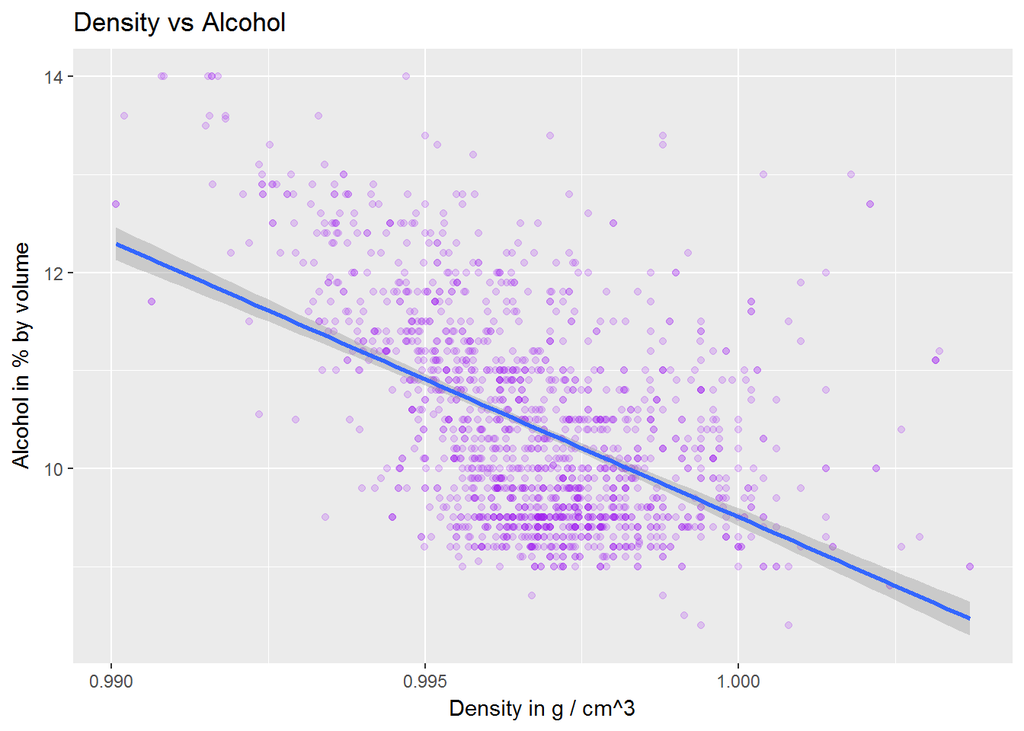

Although density has a correlation with quality, I believe this is caused by the effect that primarily alcohol and fixed acidity have on density. Alcohol lowers the density, residual sugar, citric acid and fixed acidity raises the density.

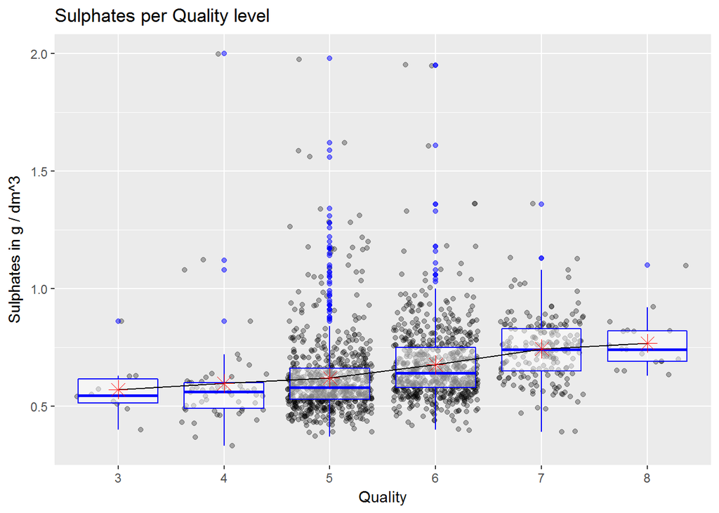

Higher quality wines have more sulphates on average. Between quality 7 and 8 sulphates are not a discriminating factor anymore.

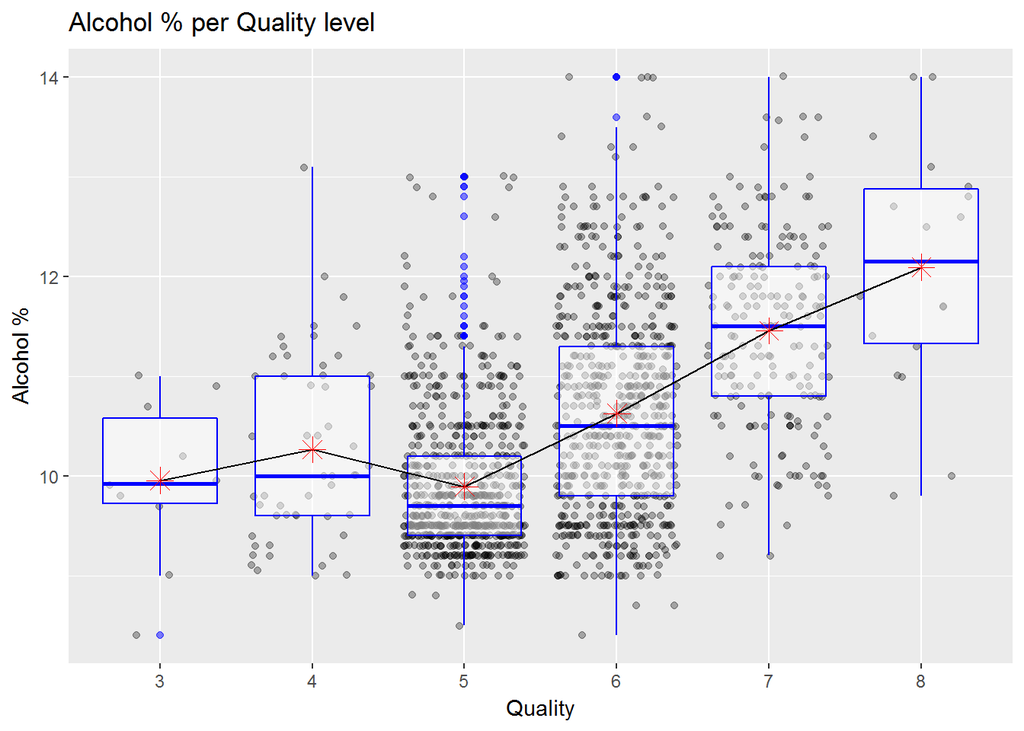

Alcohol has the strongest and positive correlation with quality (+0.48). I notice a strange dip in what seems a linear relation between the two at quality level 5, both for mean and median. Is that because the SO2 amount at quality level 5 is very high compared to the other quality levels? You could also look at it as follows from quality level 5 till 8 there is a lineair raise in quality with the alcohol %. The same form level 3 till 4. But from 3 till 4 the raise is less steep and the mean and median % is higher then 5.

# Bivariate Analysis

### How did the feature of interest vary with other features in the dataset?

The feature of interest is quality. I found a 5 interesting correlations in order of their magnitude:

1. Alcohol %: Highest correlation with quality of +0.48. Higher quality wines on average have higher alcohol levels, but there is a dip on quality level 5. I wonder if this dip can be explained by the high SO2 levels on quality level 5. I checked quality level 5 for the other variables and PH shows a simular, though difficult to see, dip. I want to examine alcohol, bound SO2, PH and quality with one another.
2. Volatile Acidity: Correlation -0.39. Higher quality wines tend to have lower volitale acidity levels. Again, between quality levels 7 and 8 I don’t see much difference, except that the standard deviation for level 8 is smaller.
3. Sulphates: Correlation +0.25. Higher quality wines tend to have higher sulphates levels. Between quality levels 7 and 8 the median level is the same, but the standard deviation on level 8 is much smaller.
4. Citric Acid: Correlation +0.23. Higher quality wines tend to have higher citric acid levels. Between quality levels 7 and 8 I don’t see much difference.
5. Bound Sulphur Dioxide: Correlation -0.21. I calculated the bound SO2 by removing the free SO2 from the total SO2. The bound SO2 has the strongest correlation with quality of the three. They all have a normal distribution, meaning that both low and high quality wines have on average low levels of SO2 and medium quality wines have high levels of SO2.

### Did you observe any interesting relationships between the other features?

I expected that Citric acid and fixed acidity would have a negative correlation with ph, I didn’t expect volatile acidity to have a positive correlation. I think, that in this case it is relative, meaning, they all contribute to the acidity levels, but volatile acidity contributes much less, and therefore contibutes to Ph levels on the high end of the range.

Density has a relation with four variables: Alcohol lowers the density, residual sugar, citric acid and fixed acidity raises the density.

### What was the strongest relationship you found?

The strongest relation I found was between total SO2 and bound SO2. But since I derived bound SO2 from total SO2, this is no real surprise.

The next strongest relation I found between PH and fixed acidity (-0.68).

The strongest relation I found with the feature of interest quality was with alcohol (+0.48).

# Multivariate Plots Section

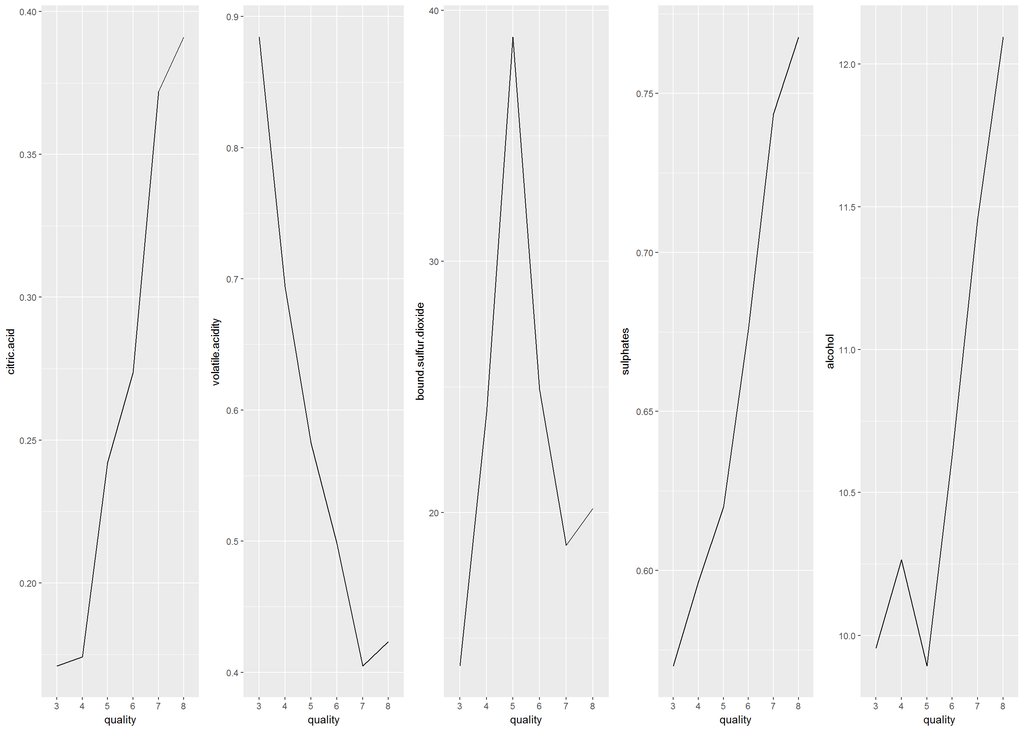

The 5 most important correlations with quality.

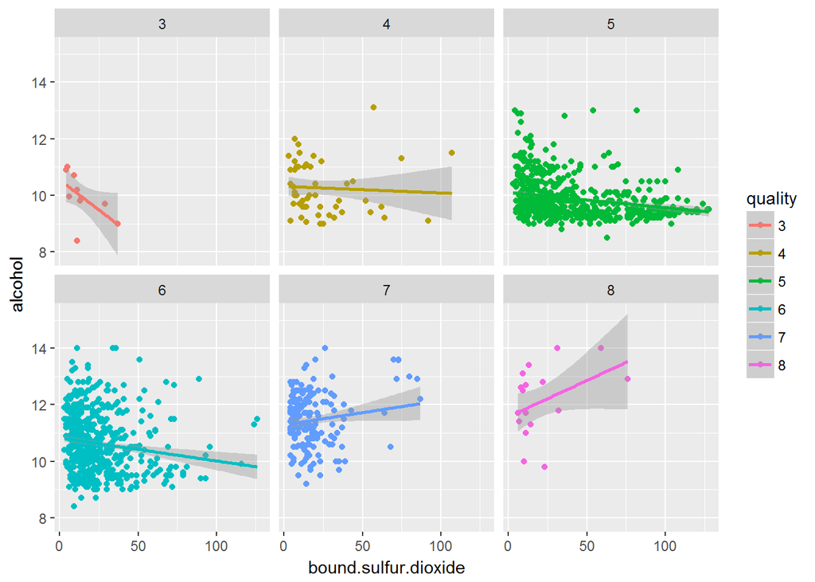

Lower alcohol % gives a lower quality, but with the right amount of bound sulfur dioxide, lower % alcohol wines can be get a higher quality level.

```
##
## Calls:
## m1: lm(formula = quality ~ alcohol, data = RW)
## m2: lm(formula = quality ~ alcohol + volatile.acidity, data = RW)
## m3: lm(formula = quality ~ alcohol + volatile.acidity + sulphates,
##     data = RW)
## m4: lm(formula = quality ~ alcohol + volatile.acidity + sulphates +
##     citric.acid, data = RW)
## m5: lm(formula = quality ~ alcohol + volatile.acidity + sulphates +
##     citric.acid + bound.sulfur.dioxide, data = RW)
##
## ================================================================
##                           m1      m2      m3      m4      m5
## ----------------------------------------------------------------
##   (Intercept)           -0.167   1.043   0.547   0.584   0.837
##
##   alcohol                0.365   0.319   0.314   0.314   0.293
##
##   volatile.acidity              -1.393  -1.223  -1.268  -1.198
##
##   sulphates                              0.697   0.714   0.748
##
##   citric.acid                                   -0.081  -0.024
##
##   bound.sulfur.dioxide                                  -0.004
##
## ----------------------------------------------------------------
##   Deviance                 0.0     0.0     0.0     0.0     0.0
##   N                     1589    1589    1589    1589    1589
## ================================================================
```

# Multivariate Analysis

### Bound sulfur dioxide and alcohol vs quality

Bound sulfur dioxide levels bigger than around 25mg per dm^3 seem to raise the quality level of wines containing lower % level of alcohol. Between quality levels 4 and 5 there is a slight drop in average alcohol %, but there is a bigger spread in bound sulfur dioxide. At level 6, the spread of sulfur dioxide is again smaller, but from this point on, alcohol % starts rising.

### Lineair multivariable model

the lineiar multivariable model for the wine quality is as follows:

Quality = 0.837 + (0.293 * alcohol %) - (1.198 * volatile acidity) + (0.748 * sulphates) - (0.024 * citric acid) - (0.004 * bound sulfur dioxide)

The model does not take into account the how the relation between higher bound sulfur dioxide levels and lower alchol % can influence the wine quality.

# Final Plots and Summary

### Plot One

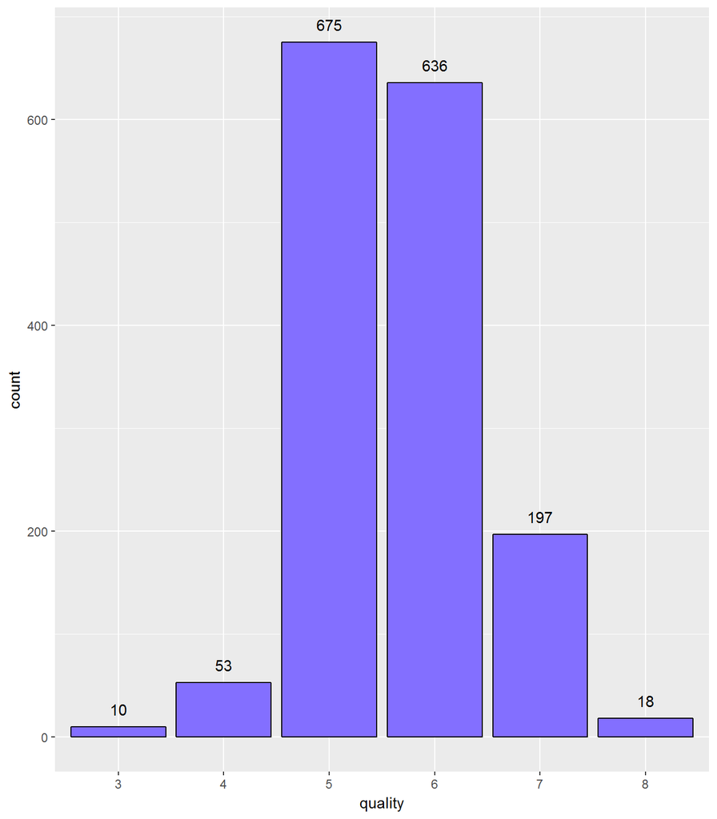

### Plot Two

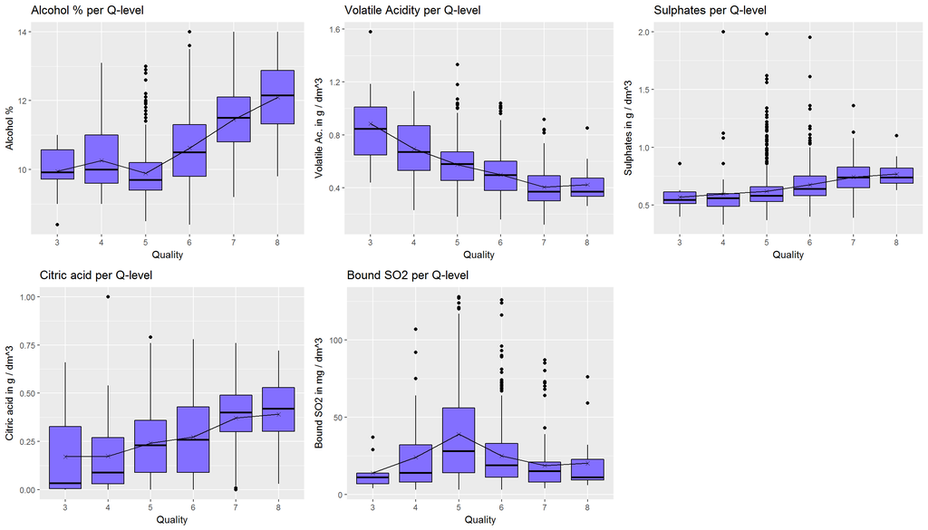

### Description Two

In order of their correlation with quality, the five features with the highest correlation are shown. All features except bound SO2 show a linear relationship with quality. Alcohol % shows a dip in at quality level 5 in it’s linear relationship with quality where bound SO2 shows a peak.

In order of their correlation the following features influence quality:  
* Alcohol  
* Volatile acidity  
* Sulphates  
* Citric acid

Bound SO2 seems to “boost” the quality of red wine when alcohol % is low.

### Plot Three

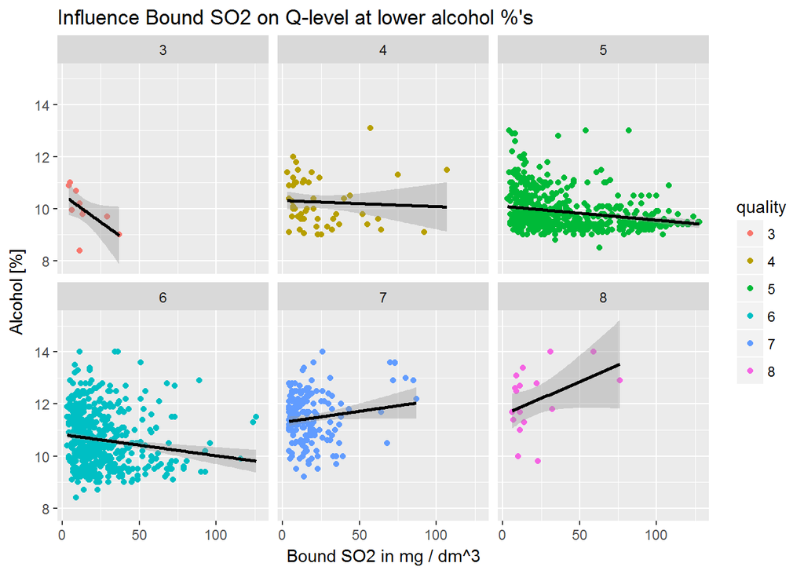

### Description Three

Bound sulfur dioxide levels bigger than around 25mg per dm^3 seem to raise the quality level of wines containing lower % level of alcohol. When alcohol % rises, the influence of bound SO2 deminishes.

# Reflection

In retrospective, the most difficult part I found was to determine when to stop investigating features or combinations of features and when to move on. For me it is not an exact science and it took me some time to decide that there was nothing more to discover, although later on I sometimes needed to revisit the topic.

What went well was following the univariate, bivariate and multivariate approach. This helped me to focus and build up the story I wanted to tell. What also worked out well was my decision to calculate bound SO2 from free and total SO2. There was a stronger correlation with bound SO2 and quality then with the total/free SO2 and quality. What did surprise me was how the relation looks (with the dip).

Still, I think that wine quality can not be captured so easily by the features that were given. Wine is a complex product with much more nuances in taste and scent.

For future work I would like to have the a finer graded rating like the Robert Parker 100-point scale to see if the distribution of the wine quality is normal. Also I expect it will more insight the correlation between quality and the other features. Using the original scores by the three experts instead of one average score would already add to more granularity.

Sites used:

https://www.ncbi.nlm.nih.gov/pmc/articles/PMC3472855/  
https://www.stat.berkeley.edu/classes/s133/factors.html  
http://docs.ggplot2.org  
http://stats.idre.ucla.edu/r/modules  
http://stackoverflow.com